# Beverlyn Tucker

```
IST736_ Text Mining WK3
Professor: Dr. Ami Gates
```

## INTRODUCTION

Mainstream media is a traditional reference for news entities capable of shaping and molding opinions of the general public. The writers capable of reaching out to a different level of audiences. The dissemination of knowledge covers a wide variety of platforms, including television, online, articles, social media, and more.

The Limitless capabilities of communication allow news agencies, writers to maximize information delivery. Moreover, benefits potentially include a better-informed and engaged general public. However, the writer can express their feelings or utilizing statistics to avoid biases. The writer can analyze and write an article based on experience, observation, psychology, statistical reports, and feelings, and ideas.

This article that is going to instigate written by Russell Carlton for over nine years in the website Baseball Prospectos was he rely heavily on statistics and the psychological side of the report.

One of the main themes in text mining is text representation, which is fundamental and indispensable for text-based intelligent information processing. Generally, text representation includes two tasks: indexing and weighting. In this paper, the use of TF-IDF stands for (term frequency-inverse document frequency) is discussed in examining the relevance of key-words to documents in the corpus.

```python
import os
import nltk
from nltk.corpus import stopwords
from nltk.corpus.reader.plaintext import PlaintextCorpusReader
from nltk.stem import WordNetLemmatizer
from sklearn.feature_extraction.text import TfidfVectorizer
import re
import pandas as pd
import numpy as np
import matplotlib.pyplot as plt
%matplotlib inline
from PIL import Image
from wordcloud import WordCloud, ImageColorGenerator
import collections
```

```python
nltk.download('punkt')
nltk.download('stopwords')
nltk.download('wordnet')
```

```
True
```

```python
# Create a folder directory where the texts are located and load them into the notebook.
# Sets the directory where the files are stored for easy acces.
corpus_dir = 'Corpus/'
```

```python
# Passes the files in the directory into a new corpus that can then be parsed and studied.
new_corpus = PlaintextCorpusReader(corpus_dir, '.*')
```

```python
# Creates an array where the file names are stored for easy access.
texts = []
for file in os.listdir(corpus_dir):
    texts.append(file)

print(texts)
```

```
['Russel1.txt', 'Russel2.txt', 'Russel3.txt', 'Russel4.txt', 'Russel5.txt', 'Russel6.txt', 'Russel7.txt', 'Russel8.txt']
```

## Analysis and Model

```python
# Creates two empty arrays that will store word counts and words for each text in the corpora.
word_counts = []
word_corpus = []

# Iterates over every item in the texts array to print the word count of each text in the corpora.
for file in texts:
    file_length = len(new_corpus.words(file))
    words = new_corpus.words(file)
    word_counts.append(file_length)
    word_corpus = np.concatenate([word_corpus, words]) # Word corpus needs to be concatenated, otherwise a list is created.
    print(file, ': %d' % file_length)

# Prints the average number of words across the corpora.
print('Avg Word Count: %d' % np.mean(word_counts))
print('Total Word Count: %d' % len(word_corpus))
```

```
Russel1.txt : 1496
Russel2.txt : 2328
Russel3.txt : 960
Russel4.txt : 2276
Russel5.txt : 2537
Russel6.txt : 1847
Russel7.txt : 4430
Russel8.txt : 4438
Avg Word Count: 2539
Total Word Count: 20312
```

```python
word_corpus[1:10]
```

```
array(['Therapy', ':', 'A', 'Halladay', 'Ultimatum', 'Russell', 'A', '.',
       'Carleton'], dtype='<U32')
```

## Data Cleaning

```
-Initialize a dictionary.
-Iterate over the word corpus to remove special characters
-change all words to lower case
```

```python
# Word dictionary.
wordcount = {}

#Remove special Characters
for word in word_corpus:
    word = re.sub('[\W\_\d\0-9]', '', word).lower()
    if word not in wordcount:
        wordcount[word] = 1
    else:
        wordcount[word] += 1

        wordcount.pop('', None)

# Print the 15 most common words.
n_print = 15
word_counter = collections.Counter(wordcount)
for word, count in word_counter.most_common(n_print):
    print(word, ": %d" % count)
```

```
the : 979
a : 484
to : 456
that : 426
of : 383
in : 283
and : 275
it : 248
s : 201
is : 200
for : 188
i : 176
you : 143
but : 139
on : 132
```

# Results

## Create a data frame of the most common words and Plots

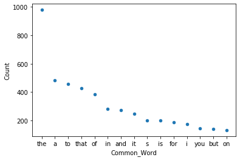

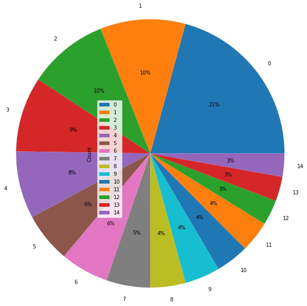

```python
lst = word_counter.most_common(n_print)
df = pd.DataFrame(lst, columns = ['Common_Word', 'Count'])

df.plot.scatter(x='Common_Word',y='Count')

##df.plot.pie(x='Common_Word',y='Count')
##plt.axis("equal")
df.plot.pie(x='Common_Word',y='Count',radius=3, autopct='%.0f%%')
plt.show()
```

[output not shown]

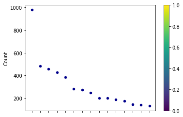

```python
ax2 = df.plot.scatter(x='Common_Word',
                      y='Count',
                      c='darkblue',
                     colormap='viridis')

df.head(15)
```

# Initial Results

```python
# Initiate English stop words
stop = stopwords.words('english')
print(stop)
```

```
['i', 'me', 'my', 'myself', 'we', 'our', 'ours', 'ourselves', 'you', "you're", "you've", "you'll", "you'd", 'your', 'yours', 'yourself', 'yourselves', 'he', 'him', 'his', 'himself', 'she', "she's", 'her', 'hers', 'herself', 'it', "it's", 'its', 'itself', 'they', 'them', 'their', 'theirs', 'themselve…
```

```python
wordcount2 = wordcount

for s in stop:
    wordcount2.pop(s, None)

# Print the 15 most common words.
n_print = 15
word_counter = collections.Counter(wordcount2)
for word, count in word_counter.most_common(n_print):
    print(word, ": %d" % count)
```

```
would : 71
game : 69
shift : 69
first : 64
time : 59
players : 58
one : 55
games : 49
get : 45
baseball : 41
might : 39
see : 38
even : 37
going : 37
play : 35
```

## Results

```
-After utilizing english stop words the data seems is very clean.
-Next step is to create data frame then Plot the results.
```

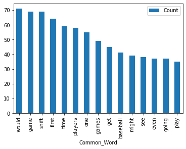

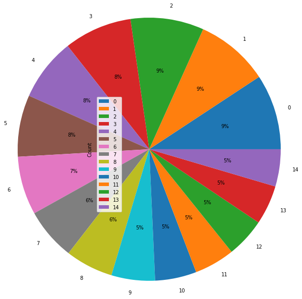

```python
# Create a data frame of the most common words

lst = word_counter.most_common(n_print)
df = pd.DataFrame(lst, columns = ['Common_Word', 'Count'])
df.plot.bar(x='Common_Word',y='Count')
df2 = pd.DataFrame(lst, columns = ['Common_Word', 'Count'])
df2.plot.pie(x='Common_Word',y='Count', radius=3, autopct='%.0f%%')
```

[output not shown]

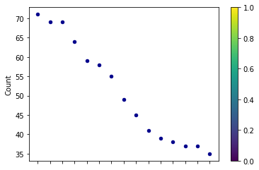

```python
ax2 = df.plot.scatter(x='Common_Word',
                      y='Count',
                      c='darkblue',
                     colormap='viridis')

df2.head(15)
```

## Results after using stop words

After removing stop words, the results much better. It appears the most frequent words use.

## Nex Step initiates a new array to insert each file into the corpora array.

```python
# A new array
corpora = []

# Insert each file into the corpora array.
for file in texts:
    corpus = new_corpus.raw(file)
    corpora.append(corpus)
```

```python
corpora
```

```
['Baseball Therapy: A Halladay Ultimatum\r\nRussell A. Carleton \r\nDecember 8, 2009 \r\n\r\nFlash forward a few weeks, in Toronto, on a sports-talk radio show.\r\n“Today in a blockbuster deal, the Toronto Blue Jays have parted ways with former Cy Young Award-winner Roy Halladay, trading him to the …
 'Baseball Therapy: Is There Really Racism in the Broadcast Booth?\r\nRussell A. Carleton \r\nSeptember 5, 2012 \r\n\r\nLast week, in Atlantic magazine, two researchers published the results of a study with a very unsettling conclusion: there is subtle racism at work in the broadcast booth in Major …
 'BP Unfiltered: Daddy, What’s Replacement Level?\r\nRussell A. Carleton \r\nMarch 4, 2013 \r\n\r\nIn the pages of yesterday’s Boston Globe, veteran sports reporter Bob Ryan\xa0declared war on WAR. We get that one a lot. But the unusual part of this particular declaration was that it was based on th…
 'Baseball Therapy: Introducing My Daughter to Baseball\r\nRussell A. Carleton \r\nJune 3, 2014 \r\n\r\nPardon me while I close the spreadsheet this week. Last Monday (Memorial Day), I had one of those life-marking moments. I got to take my daughter (N), a couple weeks shy of her fifth birthday, to …
 "Baseball Therapy: How to Vote Strategically for the Hall of Fame\r\nRussell A. Carleton \r\nDecember 30, 2014 \r\n\r\nIt’s Hall of Fame time again. And since there’s not a lot to do this week—it's something of a mutual agreement that teams give their employees the last week of the year off, so tha…
 'Baseball Therapy: Why Do Pitchers Get Tired?\r\nRussell A. Carleton \r\nSeptember 22, 2015 \r\n \r\nA couple of weeks ago, I was listening to a podcast in which some French-Canadian guy whose favorite team doesn’t exist anymore was interviewing former major-league pitcher Mark Mulder. They were ta…
 'Baseball Therapy: Long Live the Shift!\r\nRussell A. Carleton \r\nDecember 13, 2018 \r\n\r\nAccording to recent reports, Major League Baseball is considering banning the infield shift.\r\n*sigh*\r\nWarning! Gory Mathematical Details Ahead!\r\nLet’s take this one part at a time.\r\n1. How do you en…
 'Baseball Therapy: The “Tell Him, Wash” Theory of WAR\r\nRussell A. Carleton \r\nAugust 17, 2018 \r\n \r\nLast week, we talked about what happens in an emergency. What happens when you get to the 14th inning, and through some combination of pinch-hitting, injury, or “hey, why not?” a player appears…
```

## Lemmatisation

Lemmatisation is a way to reduce the word to root synonym of a word. Unlike Stemming, Lemmatisation makes sure that the reduced word is again a dictionary word (word present in the same language). WordNetLemmatizer can be used to lemmatize any word.

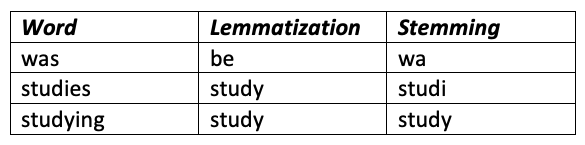

## Initialize vectorizer and then corpora is parsed through the lemmaitized tokenizer then inittialize the victorozer

Now the data is clean is time to analyze the TF-IDF. This process will use the following -Iterate the process by removing stop words, special characters, then to analyze the TF-IDF will utilize lemm_words,min_df=0.2, max_df=5, analyzer='word', max_features=500)

```python
# Lemmatization of the corpora to group words.
lemmatizer = WordNetLemmatizer()

# Define the lemmatizer then inserted into the TF-IDF tokenizer
def lemm_words(doc):
    return (lemmatizer.lemmatize(w) for w in vectorizer(doc))

#Initialize vectorizer and then corpora is parsed through the lemmaitized tokenize
vectorizer = TfidfVectorizer(token_pattern='[^\W\_\0-9]+', stop_words='english').build_tokenizer()
tf_lemm = TfidfVectorizer(tokenizer=lemm_words, token_pattern='[^\W\_\0-9]+', stop_words='english', min_df=0.2, max_df=5,
                          analyzer='word', max_features=500)
results = tf_lemm.fit_transform(corpora)

print(results.shape)
```

```
(8, 500)
```

```python
# Build data frames to store words and TF-IDF results
words, values = pd.DataFrame(np.array(tf_lemm.get_feature_names())), pd.DataFrame(np.array(results.mean(axis=0))).transpose()

# Build a dataframe with the words and tf-idf results to view words with both the highest and lowest scores.
final_results = pd.concat([words, values], axis=1)
final_results.columns = ['Words', 'tf-idf']
final_results = final_results.sort_values(by=['tf-idf'], ascending=False)
```

## Results:

```
-  Top5 highest frequency and
-  Top5 lowest frequency
```

```python
print('Top 5 highest frequency: ')
print(final_results.iloc[:5, :], '\n')

print('Bottom 5 lowest frequency: ')
print(final_results.iloc[495:, :])
```

```
Top 5 highest frequency:
       Words    tf-idf
35      ball  0.101998
320    pitch  0.093277
321  pitcher  0.088005
51      blue  0.087303
183    group  0.074530

Bottom 5 lowest frequency:
       Words   tf-idf
45   benefit  0.00402
208  imagine  0.00402
104   decent  0.00402
3    account  0.00402
184  growing  0.00402
```

## TF-IDF Analysis

The baseball articles, it makes sense that the most common words, or rather the most weight is attributed, are those that reflect upon baseball itself. The top 5 frequency words like 'ball,' 'pitch,' 'pitcher,' and group, but one thing that does not make sense is the word blue. It might be during the play; the player doesn't feel right might due to the players injured in games. It seems this is not a common word for a baseball. The lowest five words make more sense.

## Create a picture visualization from the results above.

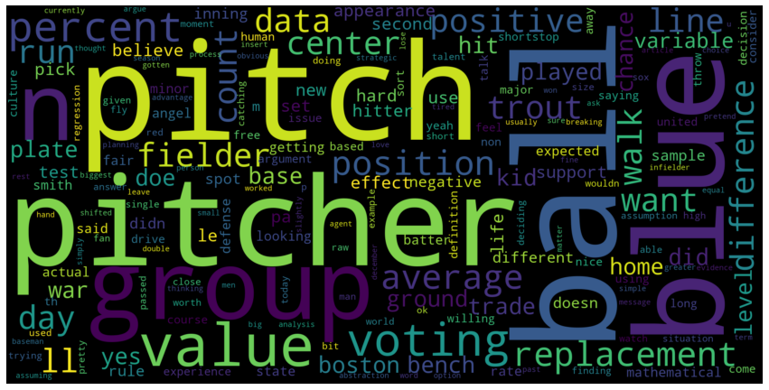

```python
# Create a dictionary with the words and TF-IDF values that will be passed into WordCloud()
d = {}
for a, x in final_results.values:
    d[a] = x

# Adjust image parameters to increase height and width of figure, create word cloud, and show image
plt.rcParams['figure.figsize'] = [15, 10]
wordcloud = WordCloud(scale=5)
wordcloud.generate_from_frequencies(frequencies=d)
plt.figure()
plt.imshow(wordcloud, interpolation="bilinear")
plt.axis("off")
plt.show()
```

## Conclusion

Using term frequency and inverse document frequency allows us to find words characteristic for one document within a collection of documents, whether that document is a novel, articles, physics text web page. Exploring term frequency can give us insight into how language is used in a collection of natural language.

Current text mining products and applications are still tools designed for trained knowledge specialists. Future text mining tools, as part of the knowledge management systems, should be readily usable by technical users and management executives. There have been some efforts in developing systems that interpret natural language queries and automatically perform the appropriate mining operations. Text mining tools could also appear in the form of intelligent personal assistants. Under the agent paradigm, a personal miner would learn a user’s profile, conduct text mining operations automatically, and forward information without requiring an explicit request from the user.